某借贷平台业务数据分析报告---XHY-2025/4

# 项目介绍

现有两份来自于某借贷平台的业务数据集，一份是借款数据集LP(Loan Characteristic)，一份是还款数据集LP(Loan Periodic)。所提供数据包含了成交时间从2015年1月1日到2017年1月30日的328553支信用标。  
基于该数据集，本报告介绍了包括数据整理，清洗，用户画像分析，逾期风险分析，RFM用户分群等内容，并给出运营优化建议。

**关键词**：Pandas数据分析处理，EDA，可视化

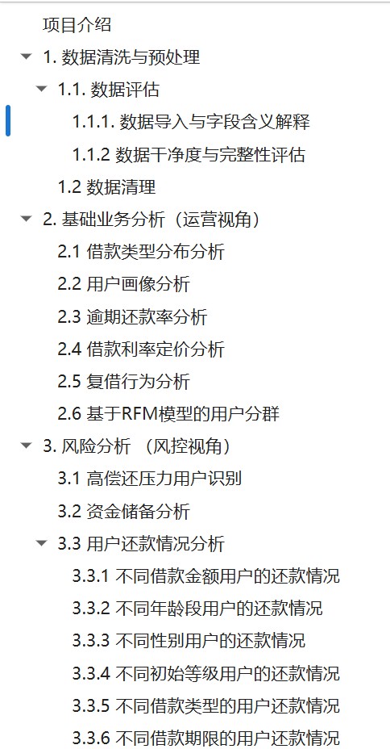

# 1. 数据清洗与预处理

## 1.1. 数据评估

### 1.1.1. 数据导入与字段含义解释

导入两份数据集并分别查看头5行

```python
import pandas as pd
LC=pd.read_csv("LC.csv")
LP=pd.read_csv("LP.csv")
LC.head(5)
```

|  | ListingId | 借款金额 | 借款期限 | 借款利率 | 借款成功日期 | 初始评级 | 借款类型 | 是否首标 | 年龄 | 性别 | ... | 户口认证 | 视频认证 | 学历认证 | 征信认证 | 淘宝认证 | 历史成功借款次数 | 历史成功借款金额 | 总待还本金 | 历史正常还款期数 | 历史逾期还款期数 |
| --- | --- | --- | --- | --- | --- | --- | --- | --- | --- | --- | --- | --- | --- | --- | --- | --- | --- | --- | --- | --- | --- |
| 0 | 126541 | 18000 | 12 | 18.0 | 2015-05-04 | C | 其他 | 否 | 35 | 男 | ... | 未成功认证 | 成功认证 | 未成功认证 | 未成功认证 | 未成功认证 | 11 | 40326.0 | 8712.73 | 57 | 16 |
| 1 | 133291 | 9453 | 12 | 20.0 | 2015-03-16 | D | 其他 | 否 | 34 | 男 | ... | 成功认证 | 未成功认证 | 未成功认证 | 未成功认证 | 未成功认证 | 4 | 14500.0 | 7890.64 | 13 | 1 |
| 2 | 142421 | 27000 | 24 | 20.0 | 2016-04-26 | E | 普通 | 否 | 41 | 男 | ... | 未成功认证 | 未成功认证 | 未成功认证 | 未成功认证 | 未成功认证 | 5 | 21894.0 | 11726.32 | 25 | 3 |
| 3 | 149711 | 25000 | 12 | 18.0 | 2015-03-30 | C | 其他 | 否 | 34 | 男 | ... | 成功认证 | 成功认证 | 未成功认证 | 未成功认证 | 未成功认证 | 6 | 36190.0 | 9703.41 | 41 | 1 |
| 4 | 152141 | 20000 | 6 | 16.0 | 2015-01-22 | C | 电商 | 否 | 24 | 男 | ... | 成功认证 | 成功认证 | 未成功认证 | 未成功认证 | 未成功认证 | 13 | 77945.0 | 0.00 | 118 | 14 |

5 rows × 21 columns

```python
LP.head(5)
```

|  | ListingId | 期数 | 还款状态 | 应还本金 | 应还利息 | 剩余本金 | 剩余利息 | 到期日期 | 还款日期 | recorddate |
| --- | --- | --- | --- | --- | --- | --- | --- | --- | --- | --- |
| 0 | 126541 | 1 | 1 | 1380.23 | 270.00 | 0.0 | 0.0 | 2015-06-04 | 2015-06-04 | 2017-02-22 |
| 1 | 126541 | 2 | 1 | 1400.94 | 249.29 | 0.0 | 0.0 | 2015-07-04 | 2015-07-04 | 2017-02-22 |
| 2 | 126541 | 3 | 1 | 1421.95 | 228.28 | 0.0 | 0.0 | 2015-08-04 | 2015-08-04 | 2017-02-22 |
| 3 | 126541 | 4 | 1 | 1443.28 | 206.95 | 0.0 | 0.0 | 2015-09-04 | 2015-09-04 | 2017-02-22 |
| 4 | 126541 | 5 | 1 | 1464.93 | 185.30 | 0.0 | 0.0 | 2015-10-04 | 2015-10-04 | 2017-02-22 |

查看两份数据集的基本信息

```python
LC.info()
```

```
<class 'pandas.core.frame.DataFrame'>
RangeIndex: 328553 entries, 0 to 328552
Data columns (total 21 columns):
 #   Column     Non-Null Count   Dtype
---  ------     --------------   -----
 0   ListingId  328553 non-null  int64
 1   借款金额       328553 non-null  int64
 2   借款期限       328553 non-null  int64
 3   借款利率       328553 non-null  float64
 4   借款成功日期     328553 non-null  object
 5   初始评级       328553 non-null  object
 6   借款类型       328553 non-null  object
 7   是否首标       328553 non-null  object
 8   年龄         328553 non-null  int64
 9   性别         328553 non-null  object
 10  手机认证       328553 non-null  object
 11  户口认证       328553 non-null  object
 12  视频认证       328553 non-null  object
 13  学历认证       328553 non-null  object
 14  征信认证       328553 non-null  object
 15  淘宝认证       328553 non-null  object
 16  历史成功借款次数   328553 non-null  int64
 17  历史成功借款金额   328553 non-null  float64
 18  总待还本金      328553 non-null  float64
 19  历史正常还款期数   328553 non-null  int64
 20  历史逾期还款期数   328553 non-null  int64
dtypes: float64(3), int64(7), object(11)
memory usage: 52.6+ MB
```

其中，`ListingId`是用户序号，是唯一标识符；借款期限按月计；借款利率为年化利率；初始等级：列表成交时的信用评级A-F；借款类型：分为‘电商’，‘APP闪电’，‘普通’和‘其他’。  
此外，年龄是指借款人借款成功时的年龄，手机/户口/视频认证是指借款人手机实名/户口/视频认证是否成功。  
学历认证成功则表示有大专及以上学历，征信认证成功表示有人行征信报告，淘宝认证成功则表示为淘宝店主。

```python
LP.info(show_counts=True)#由于数据条太多，需要设置show_counts=True，否则会不显示（这个默认机制奇奇怪怪的....）
```

[output not shown]

其中，`ListingId`与借款数据集中同名字段一致；`recorddate`：记录日；还款状态：到记录日的当期状态，分为0-”未还款“，1-”已正常还款“，2-”已逾期还款“，3-”已提前还清该标全部欠款“，4-”已部分还款“

基于上面通过`info()`打印的列名信息，我们可以发现几个潜在的有关数据类型的问题：  
`ListingId`的数据类型应为字符串，而不是整数；借款成功日期，还款日期，`recorddate`的数据类型应为日期时间，而不是字符串，所以需要对其类型进行转换

另外，从打印出的info信息可以看到，所有列下值的个数相等，说明数据集无缺失值

### 1.1.2 数据干净度与完整性评估

首先，通过描述性统计方法.describe()查看两份数据集的统计特征，此步骤是为了检验数据集中是否存在异常值，如借款金额≤0,年龄过大等。

```python
LC.describe()
```

|  | ListingId | 借款金额 | 借款期限 | 借款利率 | 年龄 | 历史成功借款次数 | 历史成功借款金额 | 总待还本金 | 历史正常还款期数 | 历史逾期还款期数 |
| --- | --- | --- | --- | --- | --- | --- | --- | --- | --- | --- |
| count | 3.285530e+05 | 328553.000000 | 328553.000000 | 328553.000000 | 328553.000000 | 328553.000000 | 3.285530e+05 | 3.285530e+05 | 328553.000000 | 328553.000000 |
| mean | 1.907948e+07 | 4423.816906 | 10.213594 | 20.601439 | 29.143042 | 2.323159 | 8.785857e+03 | 3.721665e+03 | 9.947658 | 0.423250 |
| std | 8.375769e+06 | 11219.664024 | 2.780444 | 1.772408 | 6.624286 | 2.922361 | 3.502736e+04 | 8.626061e+03 | 14.839899 | 1.595681 |
| min | 1.265410e+05 | 100.000000 | 1.000000 | 6.500000 | 17.000000 | 0.000000 | 0.000000e+00 | 0.000000e+00 | 0.000000 | 0.000000 |
| 25% | 1.190887e+07 | 2033.000000 | 6.000000 | 20.000000 | 24.000000 | 0.000000 | 0.000000e+00 | 0.000000e+00 | 0.000000 | 0.000000 |
| 50% | 1.952325e+07 | 3397.000000 | 12.000000 | 20.000000 | 28.000000 | 2.000000 | 5.000000e+03 | 2.542410e+03 | 5.000000 | 0.000000 |
| 75% | 2.629862e+07 | 5230.000000 | 12.000000 | 22.000000 | 33.000000 | 3.000000 | 1.035500e+04 | 5.446810e+03 | 13.000000 | 0.000000 |
| max | 3.281953e+07 | 500000.000000 | 24.000000 | 24.000000 | 56.000000 | 649.000000 | 7.405926e+06 | 1.172653e+06 | 2507.000000 | 60.000000 |

观察一下年龄分布，最小17岁，最大56岁，平均年龄29岁，33岁以下的占比超过了75%。说明用户整体还是青年。

将年龄分为'17-25', '25-30', '30-35', '35-40', '40+'比较合理

观察一下借款金额分布，最小借款金额为100元，最大为50万元，平均值为4424元，低于5230的借款金额占到了75%。

说明应该是小额借款比较多。将借款金额分为0-2000，2000-3500，3500-5500，5500以上比较合理

```python
LP.describe()
```

|  | ListingId | 期数 | 还款状态 | 应还本金 | 应还利息 | 剩余本金 | 剩余利息 |
| --- | --- | --- | --- | --- | --- | --- | --- |
| count | 3.203276e+06 | 3.203276e+06 | 3.203276e+06 | 3.203276e+06 | 3.203276e+06 | 3.203276e+06 | 3.203276e+06 |
| mean | 1.947391e+07 | 5.904377e+00 | 6.037828e-01 | 4.604506e+02 | 4.232540e+01 | 1.846682e+02 | 1.472581e+01 |
| std | 8.312219e+06 | 3.455267e+00 | 6.684636e-01 | 2.041906e+03 | 8.346626e+01 | 4.012435e+02 | 2.999337e+01 |
| min | 1.265410e+05 | 1.000000e+00 | 0.000000e+00 | 0.000000e+00 | 0.000000e+00 | 0.000000e+00 | 0.000000e+00 |
| 25% | 1.222287e+07 | 3.000000e+00 | 0.000000e+00 | 1.881500e+02 | 1.301000e+01 | 0.000000e+00 | 0.000000e+00 |
| 50% | 2.025666e+07 | 6.000000e+00 | 1.000000e+00 | 3.309400e+02 | 2.978000e+01 | 0.000000e+00 | 0.000000e+00 |
| 75% | 2.661693e+07 | 9.000000e+00 | 1.000000e+00 | 5.123400e+02 | 5.539000e+01 | 2.991400e+02 | 1.968000e+01 |
| max | 3.281953e+07 | 2.400000e+01 | 4.000000e+00 | 5.000000e+05 | 1.875000e+04 | 1.000000e+05 | 3.978370e+03 |

可以看到，所有列的统计特征都在合理范围内。前面已经提到，在借款数据集LC中，`ListingId`是唯一标识符，所以我们还需要检验是否存在同一个客户在同个时间借了完全相同的一笔钱，这也是为了检验是否存在重复值。

```python
LC.duplicated(subset=["ListingId","借款成功日期"])
```

```
0         False
1         False
2         False
3         False
4         False
          ...
328548    False
328549    False
328550    False
328551    False
328552    False
Length: 328553, dtype: bool
```

## 1.2 数据清理

根据前面评估部分得到的结论，我们需要进行的数据清理包括：  
· 把`借款成功日期，还款日期，recorddate`变量的数据类型转换为日期时间  
· 把`ListingId`变量的数据类型转换为字符串

```python
LC["借款成功日期"]=pd.to_datetime(LC["借款成功日期"])
LC["ListingId"]=LC["ListingId"].astype(str)
LC.info()
```

```
<class 'pandas.core.frame.DataFrame'>
RangeIndex: 328553 entries, 0 to 328552
Data columns (total 21 columns):
 #   Column     Non-Null Count   Dtype
---  ------     --------------   -----
 0   ListingId  328553 non-null  object
 1   借款金额       328553 non-null  int64
 2   借款期限       328553 non-null  int64
 3   借款利率       328553 non-null  float64
 4   借款成功日期     328553 non-null  datetime64[ns]
 5   初始评级       328553 non-null  object
 6   借款类型       328553 non-null  object
 7   是否首标       328553 non-null  object
 8   年龄         328553 non-null  int64
 9   性别         328553 non-null  object
 10  手机认证       328553 non-null  object
 11  户口认证       328553 non-null  object
 12  视频认证       328553 non-null  object
 13  学历认证       328553 non-null  object
 14  征信认证       328553 non-null  object
 15  淘宝认证       328553 non-null  object
 16  历史成功借款次数   328553 non-null  int64
 17  历史成功借款金额   328553 non-null  float64
 18  总待还本金      328553 non-null  float64
 19  历史正常还款期数   328553 non-null  int64
 20  历史逾期还款期数   328553 non-null  int64
dtypes: datetime64[ns](1), float64(3), int64(6), object(11)
memory usage: 52.6+ MB
```

```python
LP["ListingId"]=LP["ListingId"].astype(str)
LP["recorddate"]=pd.to_datetime(LP["recorddate"])
LP["到期日期"]=pd.to_datetime(LP["到期日期"])
LP.info(show_counts=True)
```

```
<class 'pandas.core.frame.DataFrame'>
RangeIndex: 3203276 entries, 0 to 3203275
Data columns (total 10 columns):
 #   Column      Non-Null Count    Dtype
---  ------      --------------    -----
 0   ListingId   3203276 non-null  object
 1   期数          3203276 non-null  int64
 2   还款状态        3203276 non-null  int64
 3   应还本金        3203276 non-null  float64
 4   应还利息        3203276 non-null  float64
 5   剩余本金        3203276 non-null  float64
 6   剩余利息        3203276 non-null  float64
 7   到期日期        3203276 non-null  datetime64[ns]
 8   还款日期        3203276 non-null  object
 9   recorddate  3203276 non-null  datetime64[ns]
dtypes: datetime64[ns](2), float64(4), int64(2), object(2)
memory usage: 244.4+ MB
```

在对`还款日期`进行类型转换时出现错误，提示存在/N值，我们暂时不对其进行转换

在对数据集进行进一步分析之前，我们对借款数据集LC中包含”认证“字段的列的值数据类型由字符串改为bool类型，用0和1表示以便后续分析。  
复制原数据集并命名为cleaned_LC和cleaned_LP

```python
cleaned_LC=LC.copy()
cleaned_LP=LP.copy()
cleaned_LC.head()
```

|  | ListingId | 借款金额 | 借款期限 | 借款利率 | 借款成功日期 | 初始评级 | 借款类型 | 是否首标 | 年龄 | 性别 | ... | 户口认证 | 视频认证 | 学历认证 | 征信认证 | 淘宝认证 | 历史成功借款次数 | 历史成功借款金额 | 总待还本金 | 历史正常还款期数 | 历史逾期还款期数 |
| --- | --- | --- | --- | --- | --- | --- | --- | --- | --- | --- | --- | --- | --- | --- | --- | --- | --- | --- | --- | --- | --- |
| 0 | 126541 | 18000 | 12 | 18.0 | 2015-05-04 | C | 其他 | 否 | 35 | 男 | ... | 未成功认证 | 成功认证 | 未成功认证 | 未成功认证 | 未成功认证 | 11 | 40326.0 | 8712.73 | 57 | 16 |
| 1 | 133291 | 9453 | 12 | 20.0 | 2015-03-16 | D | 其他 | 否 | 34 | 男 | ... | 成功认证 | 未成功认证 | 未成功认证 | 未成功认证 | 未成功认证 | 4 | 14500.0 | 7890.64 | 13 | 1 |
| 2 | 142421 | 27000 | 24 | 20.0 | 2016-04-26 | E | 普通 | 否 | 41 | 男 | ... | 未成功认证 | 未成功认证 | 未成功认证 | 未成功认证 | 未成功认证 | 5 | 21894.0 | 11726.32 | 25 | 3 |
| 3 | 149711 | 25000 | 12 | 18.0 | 2015-03-30 | C | 其他 | 否 | 34 | 男 | ... | 成功认证 | 成功认证 | 未成功认证 | 未成功认证 | 未成功认证 | 6 | 36190.0 | 9703.41 | 41 | 1 |
| 4 | 152141 | 20000 | 6 | 16.0 | 2015-01-22 | C | 电商 | 否 | 24 | 男 | ... | 成功认证 | 成功认证 | 未成功认证 | 未成功认证 | 未成功认证 | 13 | 77945.0 | 0.00 | 118 | 14 |

5 rows × 21 columns

第一次尝试后发现转换出的值全为False，猜想这一现象由字符串前后存在空格引起，于是用.strip()去掉前后空格

```python
cert_cols = ['手机认证', '视频认证', '学历认证', '征信认证', '淘宝认证', '户口认证']
for col in cert_cols:
    cleaned_LC[col] = cleaned_LC[col].apply(lambda x: True if str(x).strip() == "成功认证" else False)
cleaned_LC.head()
```

|  | ListingId | 借款金额 | 借款期限 | 借款利率 | 借款成功日期 | 初始评级 | 借款类型 | 是否首标 | 年龄 | 性别 | ... | 户口认证 | 视频认证 | 学历认证 | 征信认证 | 淘宝认证 | 历史成功借款次数 | 历史成功借款金额 | 总待还本金 | 历史正常还款期数 | 历史逾期还款期数 |
| --- | --- | --- | --- | --- | --- | --- | --- | --- | --- | --- | --- | --- | --- | --- | --- | --- | --- | --- | --- | --- | --- |
| 0 | 126541 | 18000 | 12 | 18.0 | 2015-05-04 | C | 其他 | 否 | 35 | 男 | ... | False | True | False | False | False | 11 | 40326.0 | 8712.73 | 57 | 16 |
| 1 | 133291 | 9453 | 12 | 20.0 | 2015-03-16 | D | 其他 | 否 | 34 | 男 | ... | True | False | False | False | False | 4 | 14500.0 | 7890.64 | 13 | 1 |
| 2 | 142421 | 27000 | 24 | 20.0 | 2016-04-26 | E | 普通 | 否 | 41 | 男 | ... | False | False | False | False | False | 5 | 21894.0 | 11726.32 | 25 | 3 |
| 3 | 149711 | 25000 | 12 | 18.0 | 2015-03-30 | C | 其他 | 否 | 34 | 男 | ... | True | True | False | False | False | 6 | 36190.0 | 9703.41 | 41 | 1 |
| 4 | 152141 | 20000 | 6 | 16.0 | 2015-01-22 | C | 电商 | 否 | 24 | 男 | ... | True | True | False | False | False | 13 | 77945.0 | 0.00 | 118 | 14 |

5 rows × 21 columns

```python
cleaned_LC.info()
```

```
<class 'pandas.core.frame.DataFrame'>
RangeIndex: 328553 entries, 0 to 328552
Data columns (total 21 columns):
 #   Column     Non-Null Count   Dtype
---  ------     --------------   -----
 0   ListingId  328553 non-null  object
 1   借款金额       328553 non-null  int64
 2   借款期限       328553 non-null  int64
 3   借款利率       328553 non-null  float64
 4   借款成功日期     328553 non-null  datetime64[ns]
 5   初始评级       328553 non-null  object
 6   借款类型       328553 non-null  object
 7   是否首标       328553 non-null  object
 8   年龄         328553 non-null  int64
 9   性别         328553 non-null  object
 10  手机认证       328553 non-null  bool
 11  户口认证       328553 non-null  bool
 12  视频认证       328553 non-null  bool
 13  学历认证       328553 non-null  bool
 14  征信认证       328553 non-null  bool
 15  淘宝认证       328553 non-null  bool
 16  历史成功借款次数   328553 non-null  int64
 17  历史成功借款金额   328553 non-null  float64
 18  总待还本金      328553 non-null  float64
 19  历史正常还款期数   328553 non-null  int64
 20  历史逾期还款期数   328553 non-null  int64
dtypes: bool(6), datetime64[ns](1), float64(3), int64(6), object(5)
memory usage: 39.5+ MB
```

此时，可以看到，认证列已成功被转换为bool类型，且值与原数据集中一一对应

# 2. 基础业务分析（运营视角）

## 2.1 借款类型分布分析

**目的**：分析各借款类型数量和金额占比，识别主力产品和长尾市场（指需求不旺或销量不佳的产品所构成的市场）

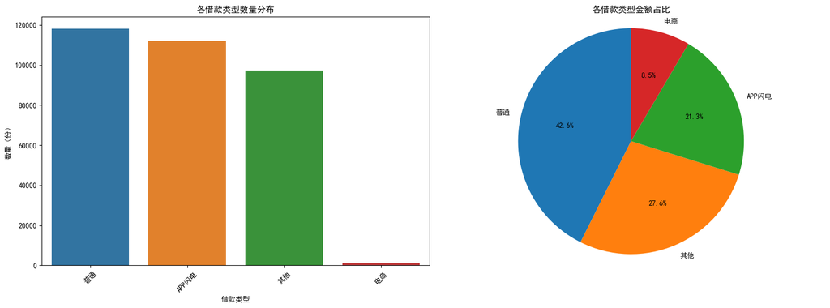

```python
import matplotlib.pyplot as plt
import seaborn as sns
from matplotlib import rcParams
# 让图表直接在jupyter中展示出来
%matplotlib inline
# 解决中文乱码问题
plt.rcParams["font.sans-serif"] = 'SimHei'
# 解决负号无法正常显示问题
plt.rcParams['axes.unicode_minus'] = False
fig, axes = plt.subplots(1, 2, figsize=(16, 6))

# 1. 各类型数量分布 (左图)
sns.countplot(data=cleaned_LC, x='借款类型', order=cleaned_LC['借款类型'].value_counts().index, ax=axes[0])
axes[0].set_title('各借款类型数量分布')
axes[0].set_ylabel('数量（份）')
axes[0].tick_params(axis='x', rotation=45)

# 2. 各类型金额占比 (右图)
type_amount = cleaned_LC.groupby('借款类型')['借款金额'].sum().sort_values(ascending=False)
type_amount_pct = type_amount / type_amount.sum() * 100
axes[1].pie(type_amount_pct, labels=type_amount_pct.index, autopct='%1.1f%%', startangle=90)
axes[1].set_title('各借款类型金额占比')
axes[1].axis('equal')  # 保证饼图是圆形的
plt.tight_layout()
plt.show()
```

结论：  
'普通型'借款产品为核心业务板块，贡献了最大的交易量和收入份额；与此同时，'电商'产品表现出明显的长尾特征

## 2.2 用户画像分析

按‘性别’、‘年龄’、‘是否首标’、‘学历认证’、‘淘宝认证’字段对‘借款金额’进行加总，并将结果可视化

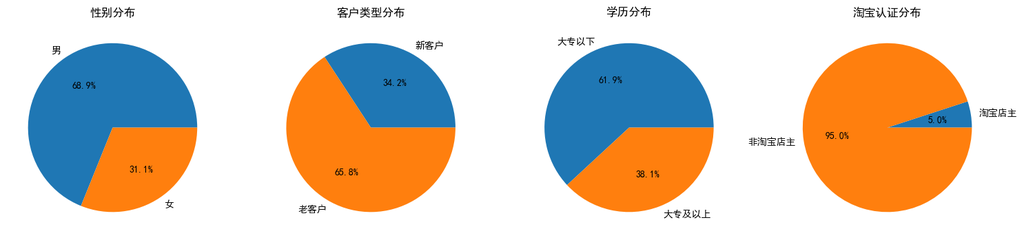

```python
# 性别分析
male = cleaned_LC[cleaned_LC['性别'] == '男']
female = cleaned_LC[cleaned_LC['性别'] == '女']
sex_data = (male['借款金额'].sum(), female['借款金额'].sum())
sex_idx = ('男', '女')
plt.figure(figsize=(15, 6))
plt.subplot(1, 4, 1)
plt.pie(sex_data, labels=sex_idx, autopct='%.1f%%')
plt.title('性别分布')

# 新老客户分析
new = cleaned_LC[cleaned_LC['是否首标'] == '是']
old = cleaned_LC[cleaned_LC['是否首标'] == '否']
newold_data = (new['借款金额'].sum(), old['借款金额'].sum())
newold_idx = ('新客户', '老客户')
plt.subplot(1, 4, 2)
plt.pie(newold_data, labels=newold_idx, autopct='%.1f%%')
plt.title('客户类型分布')

# 学历分析
ungraduate = cleaned_LC[cleaned_LC['学历认证'] == False]
graduate = cleaned_LC[cleaned_LC['学历认证'] == True]
education_data = (ungraduate['借款金额'].sum(), graduate['借款金额'].sum())
education_idx = ('大专以下', '大专及以上')
plt.subplot(1, 4, 3)
plt.pie(education_data, labels=education_idx, autopct='%.1f%%')
plt.title('学历分布')

# 淘宝认证分析
owner = cleaned_LC[cleaned_LC['淘宝认证'] == True]
nonowner = cleaned_LC[cleaned_LC['淘宝认证'] == False]
taobao_data = (owner['借款金额'].sum(), nonowner['借款金额'].sum())
taobao_idx = ('淘宝店主', '非淘宝店主')
plt.subplot(1, 4, 4)
plt.pie(taobao_data, labels=taobao_idx, autopct='%.1f%%')
plt.title('淘宝认证分布')

plt.tight_layout()
plt.show()
```

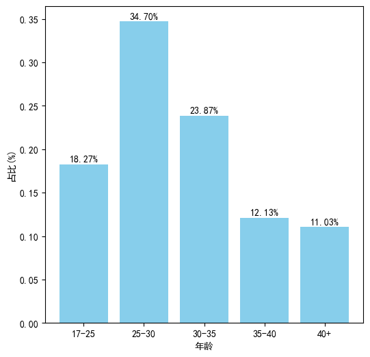

```python
#年龄分析
ageA = LC.loc[(LC['年龄'] >= 17) & (LC['年龄'] < 25)]
ageB = LC.loc[(LC['年龄'] >= 25) & (LC['年龄'] < 30)]
ageC = LC.loc[(LC['年龄'] >= 30) & (LC['年龄'] < 35)]
ageD = LC.loc[(LC['年龄'] >= 35) & (LC['年龄'] < 40)]
ageE = LC.loc[LC['年龄'] >= 40]
age = (ageA, ageB, ageC, ageD, ageE)
age_total = 0
age_percent =[]
for i in age:
    tmp = i['借款金额'].sum()
    age_percent.append(tmp)
    age_total  += tmp
age_percent /= age_total
age_idx = ['17-25', '25-30', '30-35', '35-40', '40+']
plt.figure(figsize=(6, 6))
plt.bar(age_idx, age_percent,color='skyblue')
plt.xlabel('年龄')
plt.ylabel('占比(%)')
for (a, b) in zip(age_idx, age_percent):#添加数据标签
    plt.text(a, b+0.001, '%.2f%%' % (b * 100), ha='center', va='bottom', fontsize=10)
plt.show()
```

结论：

1.男性客户的贡献的贷款金额占到了69%，高于女性客户占比，可能的原因是男性更倾向于提前消费或者在事业生活上的资金需求更高。

2.非首标的金额占比达到66%，表明复借率较高，产品粘性较高。

3.大专以下学历的贷款金额更多，其潜在原因可能有两点：一是部分用户可能并未进行学历认证；二是低学历人群可能意味着低收入，资金周转压力更高。

4.非淘宝店主的借款金额占比达95%，可能的原因是淘宝店主已步入事业的稳定器，有一定收入，借款需求低。

5.年龄段在25-30岁之间的借款金额最多，且≤35岁的人群占比超过75%，表明青年人群是该产品的消费主力军，这可能是因为该年龄段人群正处于事业的起步阶段，资金需求较高。

## 2.3 逾期还款率分析

**目的**：探究借款人的初始评级、借款类型、性别、年龄、借款金额等特征与逾期率之间关系  
其中，逾期还款率 = 历史逾期还款期数/（历史逾期还款期数+历史正常还款期数）

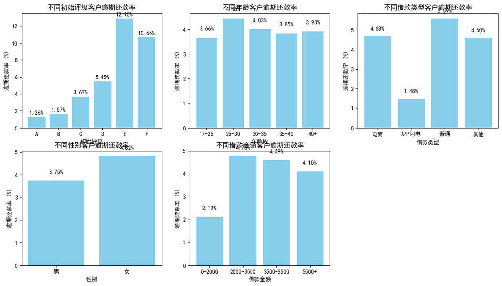

```python
def plot_overdue_rate(subplot_index, df_list, labels, xlabel, title):
    overdue_rates = []
    for df in df_list:
        rate = df['历史逾期还款期数'].sum() / (df['历史逾期还款期数'].sum() + df['历史正常还款期数'].sum()) * 100
        overdue_rates.append(rate)
    plt.subplot(2, 3, subplot_index)
    plt.bar(labels, overdue_rates, color='skyblue')
    for i, val in enumerate(overdue_rates):
        plt.text(i, val + 0.3, f'{val:.2f}%', ha='center')
    plt.xlabel(xlabel)
    plt.ylabel('逾期还款率 (%)')
    plt.title(title)

# 通用分组
def group_by_category(df, col, values):
    return [df[df[col] == val] for val in values]

# 金额分组
def group_by_amount(df):
    bins = [0, 2000, 3500, 5500, float('inf')]
    labels = ['0-2000', '2000-3500', '3500-5500', '5500+']
    df['金额区间'] = pd.cut(df['借款金额'], bins=bins, labels=labels, right=False)
    return group_by_category(df, '金额区间', labels), labels

# 年龄分组
def group_by_age(df):
    bins = [17, 25, 30, 35, 40, float('inf')]
    labels = ['17-25', '25-30', '30-35', '35-40', '40+']
    df['年龄段'] = pd.cut(df['年龄'], bins=bins, labels=labels, right=False)
    return group_by_category(df, '年龄段', labels), labels

plt.figure(figsize=(15, 8))

# 1. 初始评级
level_idx = ['A', 'B', 'C', 'D', 'E', 'F']
lev = group_by_category(cleaned_LC, '初始评级', level_idx)
plot_overdue_rate(1, lev, level_idx, '初始评级', '不同初始评级客户逾期还款率')

# 2. 年龄段
age, age_labels = group_by_age(cleaned_LC)
plot_overdue_rate(2, age, age_labels, '年龄段', '不同年龄客户逾期还款率')

# 3. 借款类型
kind_idx = ['电商', 'APP闪电', '普通', '其他']
kind = group_by_category(cleaned_LC, '借款类型', kind_idx)
plot_overdue_rate(3, kind, kind_idx, '借款类型', '不同借款类型客户逾期还款率')

# 4. 性别
sex_idx = ['男', '女']
sex = group_by_category(cleaned_LC, '性别', sex_idx)
plot_overdue_rate(4, sex, sex_idx, '性别', '不同性别客户逾期还款率')

# 5. 借款金额分段
amount, amount_idx = group_by_amount(cleaned_LC)
plot_overdue_rate(5, amount, amount_idx, '借款金额', '不同借款金额客户逾期还款率')

plt.show()
```

结论：

1.初始评级对于贷款者的还款能力有比较好的预测作用，EF两级反转可能是因为样本数量较少，也可能是因为F级用户为增加借款申请成功的几率，有意及时还款，从而保持良好的个人信用记录，提高自己的初始等级，否则，该部分群体将面临被平台”拉黑“的风险，彻底失去贷款的可能。不过，而EF两级用户逾期还款率较ABCD级用户明显增大，平台对这部分群体仍应加强审查。

2.年龄对于逾期率的分布较为平均，25-30岁的年轻人可以重点关注。

3.APP闪电的逾期还款率明显低于其他三种，故公司可以多考虑与“APP闪电”借款类型的合作。

4.女性的逾期率高于男性，可能是由于生活中男性收入较女性高造成的。

5.借款金额在2000以下的逾期还款率最低，2000-3500之间的最高，因此可以考虑增加小额贷款业务占比以降低逾期风险。

## 2.4 借款利率定价分析

**目的**: 分析不同特征下借款利率的分布差异，旨在探索借款利率定价的策略

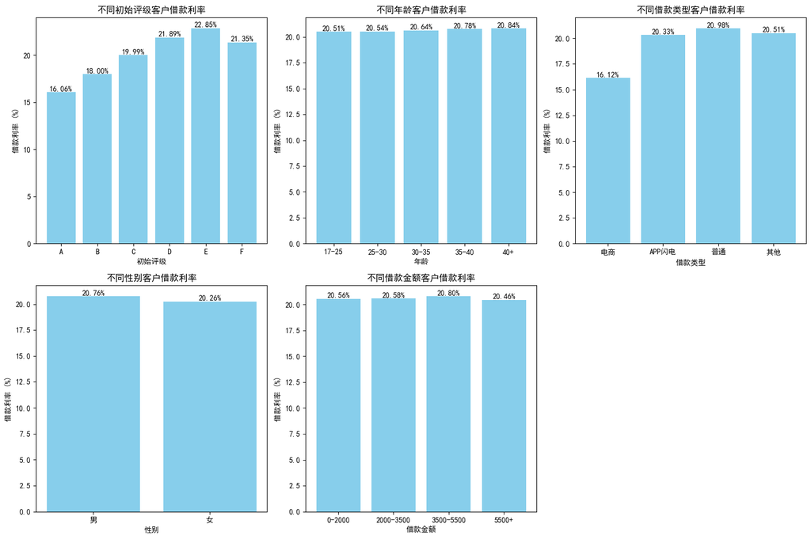

```python
def plot_interest_rate(subplot_index, df_list, labels, xlabel, title):
    avg_interest_rates = []
    for df in df_list:
        avg = df['借款利率'].mean()
        avg_interest_rates.append(avg)
    plt.subplot(2, 3, subplot_index)
    plt.bar(labels, avg_interest_rates, color='skyblue')
    for i, val in enumerate(avg_interest_rates):
        plt.text(i, val + 0.1, f'{val:.2f}%', ha='center')
    plt.xlabel(xlabel)
    plt.ylabel('借款利率 (%)')
    plt.title(title)

plt.figure(figsize=(15, 10))

plot_interest_rate(1, lev, level_idx, '初始评级', '不同初始评级客户借款利率')
plot_interest_rate(2, age, age_labels, '年龄', '不同年龄客户借款利率')
plot_interest_rate(3, kind, kind_idx, '借款类型', '不同借款类型客户借款利率')
plot_interest_rate(4, sex, sex_idx, '性别', '不同性别客户借款利率')
plot_interest_rate(5, amount, amount_idx, '借款金额', '不同借款金额客户借款利率')

plt.tight_layout()
plt.show()
```

结论：

1.不同初始评级的平均借款利率由小到大排列为A＜B＜C＜F＜D＜E。

2.不同年龄段借款利率的分布较为平均，差异性很小。

3.电商的借款利率明显低于其他三种。

4.女性所能接受的借款利率略低于男性。

5.不同借款金额下借款利率的分布较为平均，差异性很小。

## 2.5 复借行为分析

**目的**:探索数据记录的时间段内，首标用户转化为复借用户的周期和转化率

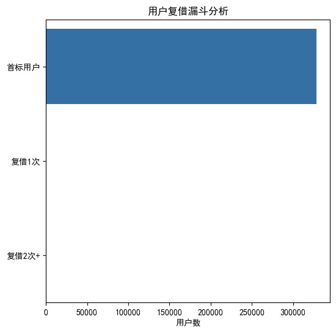

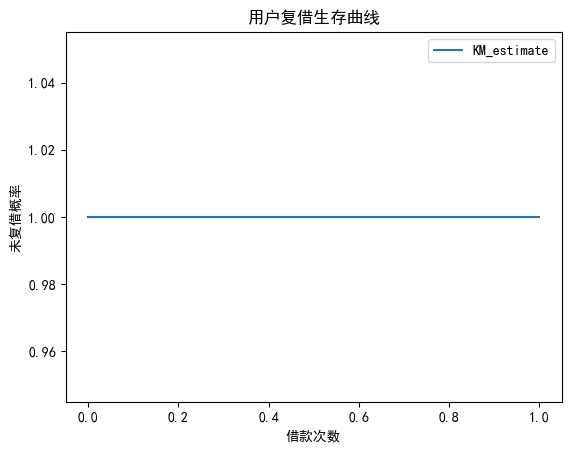

```python
# 1. 构建用户借款时序
user_history = cleaned_LC.sort_values('借款成功日期').groupby('ListingId')['借款成功日期'].agg(list)

# 2. 计算复借周期（首次借款到二次借款的天数）
def calculate_reborrow_days(dates):
    if len(dates) >= 2:
        return (dates[1] - dates[0]).days
    else:
        return np.nan
cleaned_LC['首次借款日期'] = cleaned_LC.groupby('ListingId')['借款成功日期'].transform('min')
cleaned_LC['复借周期'] = (
    (cleaned_LC['借款成功日期'] - cleaned_LC['首次借款日期']).dt.days
)

# 3. 漏斗分析
# 步骤定义：首标 -> 复借1次 -> 复借2次+
funnel = cleaned_LC.groupby('ListingId').agg(
    total_orders=('ListingId', 'count'),
    first_date=('借款成功日期', 'min')
).reset_index()

funnel_stages = [
    ('首标用户', funnel[funnel.total_orders >= 1].shape[0]),
    ('复借1次', funnel[funnel.total_orders >= 2].shape[0]),
    ('复借2次+', funnel[funnel.total_orders >= 3].shape[0])
]

stages = [s[0] for s in funnel_stages]
counts = [s[1] for s in funnel_stages]

plt.figure(figsize=(6,6))
plt.title("用户复借漏斗分析")
sns.barplot(x=counts, y=stages, palette="Blues_r")
plt.xlabel("用户数")
plt.show()

# 4. Kaplan-Meier生存曲线（分析复借概率随时间变化）
import lifelines
from lifelines import KaplanMeierFitter

# 构建生存分析数据
kmf = KaplanMeierFitter()
duration = funnel['total_orders'].apply(lambda x: x if x <=3 else 3)  # 观察前3次复借
observed = (duration > 1).astype(int)  # 是否发生复借

kmf.fit(duration, event_observed=observed)
kmf.plot_survival_function()
plt.title("用户复借生存曲线")
plt.xlabel("借款次数")
plt.ylabel("未复借概率")
plt.show()
```

从上面可以看到，在记录的时间段内，首标用户复借率为0，这可能是由于记录时间段过短(小于借款期限)或者平台对于续借机制的设计有缺陷。

## 2.6 基于RFM模型的用户分群

RFM 模型是衡量客户价值和客户创利能力的重要工具和手段，其中由3个要素构成了数据分析最好的指标，分别是：  
`R-Recency`-(最近一次购买时间)  
`F-Frequency`(购买频率)  
`M-Money`(消费金额)

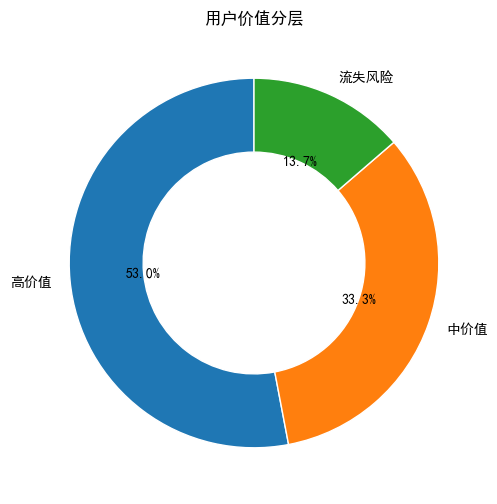

```python
# --- 1. 计算RFM指标（直接运行）---
rfm = cleaned_LC.groupby('ListingId').agg(
    Recency=('借款成功日期', lambda x: (pd.to_datetime('today') - x.max()).days),
    Frequency=('ListingId', 'count'),  # 此处全为1
    Monetary=('借款金额', 'sum')
)

# --- 2. 等宽分箱（兼容全相同值）---
def safe_cut(series, bins=5, reverse=False):
    """等宽分箱，自动处理全相同值"""
    labels = list(range(1, bins+1))
    if reverse:
        labels = labels[::-1]
    # 全相同值时直接赋中位值
    if series.nunique() == 1:
        return pd.Series(labels[len(labels)//2], index=series.index)
    return pd.cut(series, bins=bins, labels=labels)

# 分箱操作
rfm['R_Score'] = safe_cut(rfm['Recency'], bins=5, reverse=True)  # Recency越小分越高
rfm['F_Score'] = safe_cut(rfm['Frequency'], bins=5)             # 全为1时自动赋3分
rfm['M_Score'] = safe_cut(rfm['Monetary'], bins=5)

# --- 3. 生成分层并可视化 ---
rfm['层级'] = (
    rfm['R_Score'].astype(str) +
    rfm['M_Score'].astype(str)    # 因Frequency全为3，仅用R+M分层
)

# 简化层级命名
rfm['层级'] = rfm['层级'].map({
    '51': '高价值','31': '流失风险'
}).fillna('中价值')

# 绘制结果
plt.figure(figsize=(10,6))
rfm['层级'].value_counts().plot.pie(
    autopct='%1.1f%%',
    startangle=90,
    wedgeprops={'width':0.4, 'edgecolor':'w'}
)
plt.title('用户价值分层')
plt.ylabel('')
plt.show()
```

可以看到，高价值用户占比过半，在资金有限的情况下可以优先为该用户群体放宽贷款审批政策，提供优惠利好。但仍需要注意，有流失风险的用户群体仍然占据了13%，提示平台应考虑优化产品设计和贷款审批机制

整体总结与业务策略：  
1.”普通型“是该平台主力产品，“男性”、“回头客”、“青年”是平台用户群体的主要特征。

2.对于”电商“这款产品，其借款利率在所有类型产品中最低，但逾期还款率却保持在一个较高的水平，且市场占比仅为8.5%。该产品收益小，风险大，建议在该渠道上减少资金投放.

4.通过“app闪电”贷款的逾期还款率远低于其他项，约为其他借款类型的三分之一至四分之一，而平均借款利率却和其他项相差不大，证明“app闪电”是该公司优质的合作方，其所引流来的客户质量很高，平台应与“app闪电”继续加深合作。

5.小额贷（借款金额≤2000）的逾期还款率仅为其它金额段的1/2，但利率却与其它产品相当，后期应考虑个性化调整利率，比如通过适当降低小额贷利率并增加该类型业务资金储备，从而刺激该部分市场。

6.对于25-30年龄段的人群，其借款占比较大，逾期率最高，利率却与其它年龄段持平。由此，平台应谨慎对待该部分人群，对于已贷款项，应适当增加利率刺激其还款主动性。对于在审申请，应考虑增大审查力度，将过往还款信用记录纳入评价体系。

7.首标用户复购率为0，应仔细审查产品设计、放贷审批等环节是否存在重大缺陷；在留住50%的高价值用户的同时也应重点关注13%的有流失风险的用户群体

# 3. 风险分析 （风控视角）

## 3.1 高偿还压力用户识别

**目的**：待还本金压力=总待还本金/历史成功借款金额，输出待还本金压力top50的用户Id,对其进行密切监控  
当然，实际情况中输出用户数可以更多

```python
import numpy as np
cleaned_LC['待还本金压力'] = (
    cleaned_LC['总待还本金'] /
    cleaned_LC['历史成功借款金额'].replace(0, np.nan)
)

# 提取压力最大的 Top 50 的 ListingId
top50_ids = cleaned_LC.nlargest(50, '待还本金压力')['ListingId']
print("Top 50 高风险用户的 ListingId：")
print(top50_ids.tolist())
```

```
Top 50 高风险用户的 ListingId：
['2141091', '2406121', '3729541', '4439041', '4573511', '4842841', '4880731', '4906921', '5131381', '5138341', '5334221', '5378981', '5404481', '5414381', '5427021', '5428871', '5433721', '5469401', '5487151', '5494351', '5518161', '5560421', '5562821', '5581611', '5720421', '5726681', '5729771', '5…
```

## 3.2 资金储备分析

**目的**：探究每日的借款金额大概多少？波动有多大？公司每日需要准备多少资金可以保证不会出现资金短缺？

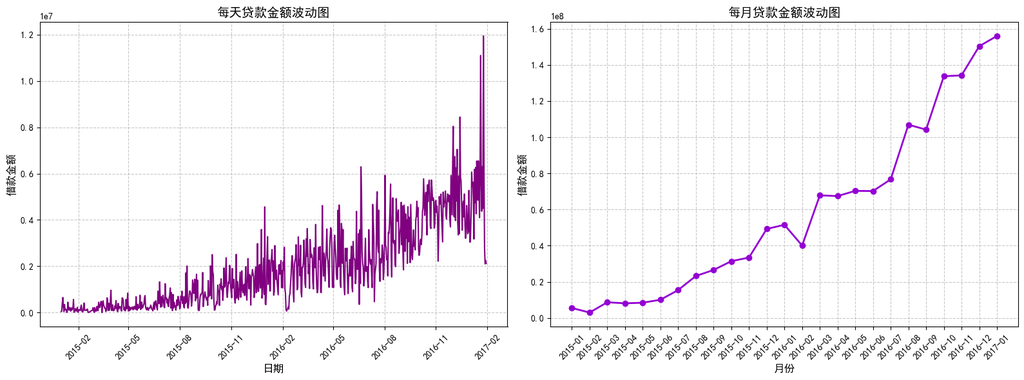

```
2017年1月平均每日贷款金额: 5204663.80
2017年1月贷款金额标准差: 2203394.14
```

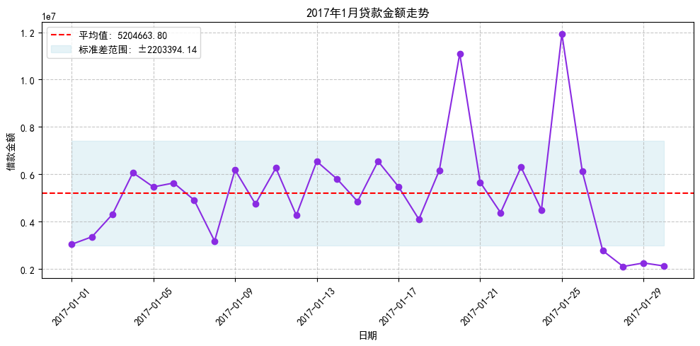

```python
from datetime import datetime
import matplotlib.dates as mdates
loan = cleaned_LC[['借款成功日期', '借款金额']].copy()
loan['借款日期'] = pd.to_datetime(loan['借款成功日期'])

# 按日期分组并求和借款金额
loan_daily = loan.groupby('借款日期')['借款金额'].sum().reset_index()
loan_daily = loan_daily.set_index('借款日期')

# 创建月份列并按月份分组求和
loan['借款成功月份'] = loan['借款日期'].dt.strftime('%Y-%m')
loan_monthly = loan.groupby('借款成功月份')['借款金额'].sum().reset_index()

# 可视化
plt.figure(figsize=(16, 6))

# 每日贷款金额走势图
plt.subplot(1, 2, 1)
plt.plot(loan_daily.index, loan_daily['借款金额'], color='purple', linewidth=1.5)
plt.xlabel('日期', fontsize=12)
plt.ylabel('借款金额', fontsize=12)
plt.title('每天贷款金额波动图', fontsize=14)
plt.grid(True, linestyle='--', alpha=0.7)
# 设置x轴日期格式
plt.gca().xaxis.set_major_formatter(mdates.DateFormatter('%Y-%m'))
plt.gca().xaxis.set_major_locator(mdates.MonthLocator(interval=3))
plt.xticks(rotation=45)

# 每月贷款金额走势图
plt.subplot(1, 2, 2)
plt.plot(loan_monthly['借款成功月份'], loan_monthly['借款金额'],
         color='darkviolet', marker='o', linewidth=2)
plt.xlabel('月份', fontsize=12)
plt.ylabel('借款金额', fontsize=12)
plt.title('每月贷款金额波动图', fontsize=14)
plt.grid(True, linestyle='--', alpha=0.7)
plt.xticks(rotation=45)

plt.tight_layout()
plt.show()

# 对2017年1月的数据继续进行分析
if '2017-01' in loan_monthly['借款成功月份'].values:
    # 过滤出2017年1月的日数据
    loan_jan_2017 = loan_daily[loan_daily.index.strftime('%Y-%m') == '2017-01']

    # 计算平均值和标准差
    avg = loan_jan_2017['借款金额'].mean()
    std = loan_jan_2017['借款金额'].std()

    print(f"2017年1月平均每日贷款金额: {avg:.2f}")
    print(f"2017年1月贷款金额标准差: {std:.2f}")

    # 可视化2017年1月数据
    plt.figure(figsize=(10, 5))
    plt.plot(loan_jan_2017.index, loan_jan_2017['借款金额'],
             color='blueviolet', marker='o', linestyle='-')
    plt.axhline(y=avg, color='red', linestyle='--', label=f'平均值: {avg:.2f}')
    plt.fill_between(loan_jan_2017.index, avg-std, avg+std,
                     color='lightblue', alpha=0.3, label=f'标准差范围: ±{std:.2f}')
    plt.xlabel('日期')
    plt.ylabel('借款金额')
    plt.title('2017年1月贷款金额走势')
    plt.legend()
    plt.grid(True, linestyle='--', alpha=0.7)
    plt.xticks(rotation=45)
    plt.tight_layout()
    plt.show()
else:
    print("数据中不包含2017年1月的记录")
```

## 3.3 用户还款情况分析

**目的**：基于LC和LP两个数据集，分析用户的还款习惯（提前一次性全部还款 、部分提前还款以及逾期还款）的金额占比。

将数据集按借款金额分组，并按还款状态和还款日期分成四种还款情况并进行统计：

（1）一次性全部还款：其还款状态标记为‘已提前还清该标全部欠款’；

（2）部分提前还款：其还款状态标记为’已正常还款’，并且当期的还款日期早于到期日期；

（3）正常还款：其还款状态标记为’已正常还款’，并且当期的还款日期即为到期日期；

（4）逾期还款：还款状态标记为‘未还款’，‘已逾期还款’或者‘已部分还款’。

用百分堆积柱状图展示在不同年龄段（17 -25 ，25 -30 ，30-35 ， 35-40 ，40+ ）, 不同性别（ 男、女），不同初始评级（A-F），不同借款类型、不同借款金额（1-2000，2000 -3500，3500-5500，5500+）、不同期数（1-24）的走势。

```python
# 删除尚未到期的记录
cleaned_LP = cleaned_LP[cleaned_LP['到期日期'] <= cleaned_LP['recorddate']]
cleaned_LC_1=cleaned_LC.copy()
# 将LC和LP两个表融合起来
LCLP = pd.merge(cleaned_LC_1, cleaned_LP, how='left', on=['ListingId'])
# 删除数据不全的记录
LCLP = LCLP.dropna(how='any')
LCLP.info()
```

```
<class 'pandas.core.frame.DataFrame'>
Index: 1030487 entries, 0 to 1603587
Data columns (total 36 columns):
 #   Column      Non-Null Count    Dtype
---  ------      --------------    -----
 0   ListingId   1030487 non-null  object
 1   借款金额        1030487 non-null  int64
 2   借款期限        1030487 non-null  int64
 3   借款利率        1030487 non-null  float64
 4   借款成功日期      1030487 non-null  datetime64[ns]
 5   初始评级        1030487 non-null  object
 6   借款类型        1030487 non-null  object
 7   是否首标        1030487 non-null  object
 8   年龄          1030487 non-null  int64
 9   性别          1030487 non-null  object
```

[output cut: 28 more lines]

```python
LCLP["到期日期"]=LCLP["到期日期"].astype(str)
LCLP.info()
```

```
<class 'pandas.core.frame.DataFrame'>
Index: 1030487 entries, 0 to 1603587
Data columns (total 36 columns):
 #   Column      Non-Null Count    Dtype
---  ------      --------------    -----
 0   ListingId   1030487 non-null  object
 1   借款金额        1030487 non-null  int64
 2   借款期限        1030487 non-null  int64
 3   借款利率        1030487 non-null  float64
 4   借款成功日期      1030487 non-null  datetime64[ns]
 5   初始评级        1030487 non-null  object
 6   借款类型        1030487 non-null  object
 7   是否首标        1030487 non-null  object
 8   年龄          1030487 non-null  int64
 9   性别          1030487 non-null  object
```

[output cut: 28 more lines]

```python
#定义用户还款习惯分析可视化函数
def repayhabit(group,num,idx,xlabel,color):
    # 一次性全部还款
    onetime = []
    for a in group:
        ot = a.loc[a['还款状态'] == 3]['应还本金'].sum(
            ) + a.loc[a['还款状态'] == 3]['应还利息'].sum()
        onetime.append(ot)
    # 部分提前还款
    partial = []
    for a in group:
        pa = a.loc[(a['还款状态'] == 1) & (a['还款日期'] < a['到期日期'])]['应还本金'].sum(
            ) + a.loc[(a['还款状态'] == 1) & (a['还款日期'] < a['到期日期'])]['应还利息'].sum()
        partial.append(pa)
    # 逾期还款
    pastdue = []
    for a in group:
        pas = a.loc[(a['还款状态'] == 2) | (a['还款状态'] == 4)|(a['还款状态'] == 0)]['应还本金'].sum() + \
            a.loc[(a['还款状态'] == 2) | (a['还款状态'] == 4)|(a['还款状态'] == 0)]['应还利息'].sum()
        pastdue.append(pas)
    # 正常还款
    normal = []
    for a in group:
        nm = a.loc[(a['还款状态'] == 1) & (a['还款日期'] == a['到期日期'])]['应还本金'].sum(
        ) + a.loc[(a['还款状态'] == 1) & (a['还款日期'] == a['到期日期'])]['应还利息'].sum()
        normal.append(nm)

    tot = []
    for i in range(num):
        t = onetime[i]+partial[i]+pastdue[i]+normal[i]
        tot.append(t)

    print(tot)

    temp = []
    for i in range(num):
        tp = (100 * onetime[i] / tot[i], 100 * partial[i] / tot[i],
                100 * normal[i] / tot[i], 100 * pastdue[i] / tot[i])
        temp.append(tp)

    df = pd.DataFrame(temp)
    df.index = idx
    df.columns = ('提前一次性', '部分提前', '正常', '逾期')
    print(df)

    df.plot(kind='bar', colormap=color, stacked=True)
    plt.ylabel('还款金额')
    plt.xlabel(xlabel)
    plt.legend(loc='best')
    plt.show()
```

### 3.3.1 不同借款金额用户的还款情况

```
[28776004.810000002, 134125171.82999998, 141010633.82, 292991424.5006]
               提前一次性       部分提前         正常         逾期
0-2000     10.337694  60.788639  16.202411  12.671256
2000-3500  12.598356  53.288757  20.708382  13.404504
3500-5500  15.032922  50.438939  22.797644  11.730494
5500+      12.167703  39.745761  38.938830   9.147706
```

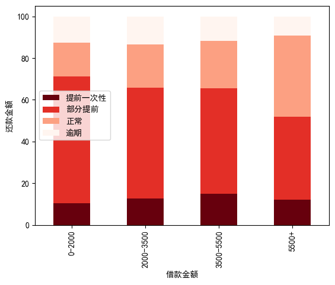

```python
amountA = LCLP.loc[(LCLP['借款金额'] > 0) & (LCLP['借款金额'] < 2000)]
amountB = LCLP.loc[(LCLP['借款金额'] >= 2000) & (LCLP['借款金额'] < 3500)]
amountC = LCLP.loc[(LCLP['借款金额'] >= 3500) & (LCLP['借款金额'] < 5500)]
amountD = LCLP.loc[(LCLP['借款金额'] >= 5500)]
amountgroup = [amountA, amountB, amountC, amountD]
repayhabit(amountgroup,4,amount_idx,'借款金额','Reds_r')
```

图上侧打印出的值为每个金鹅组中不同还款类型所占的比例值

从对借款金额分组的统计结果以及上图结果中可以看出：

1. 逾期风险在各金额组表现比较平均，其中2000-3500最大，5500+最小。
2. 随着标的金额增加，部分提前还款的总金额比例在减少，正常还款的总金额比例在增加。
3. 3500-5500组的提前一次性结清比例最高

### 3.3.2 不同年龄段用户的还款情况

```
[88266549.92999999, 204978292.7706, 152900842.2862, 80238491.70429999, 70519058.2695]
           提前一次性       部分提前         正常         逾期
17-25  13.569885  53.194607  19.885092  13.350416
25-30  14.169921  47.548300  26.644014  11.637764
30-35  12.603650  43.379544  34.322326   9.694479
35-40  10.844577  44.347819  34.687342  10.120262
40+    10.954687  42.844688  37.144625   9.056001
```

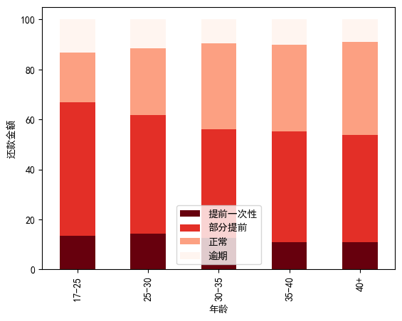

```python
ageA = LCLP.loc[(LCLP['年龄'] >= 17) & (LCLP['年龄'] < 25)]
ageB = LCLP.loc[(LCLP['年龄'] >= 25) & (LCLP['年龄'] < 30)]
ageC = LCLP.loc[(LCLP['年龄'] >= 30) & (LCLP['年龄'] < 35)]
ageD = LCLP.loc[(LCLP['年龄'] >= 35) & (LCLP['年龄'] < 40)]
ageE = LCLP.loc[LCLP['年龄'] >= 40]
age = (ageA, ageB, ageC, ageD, ageE)
repayhabit(age,5,age_idx,'年龄','Reds_r')
```

### 3.3.3 不同性别用户的还款情况

```
[436402442.6353, 160500792.32529998]
       提前一次性       部分提前         正常         逾期
男  13.380218  45.615798  30.071372  10.932611
女  11.419936  48.269955  29.557419  10.752690
```

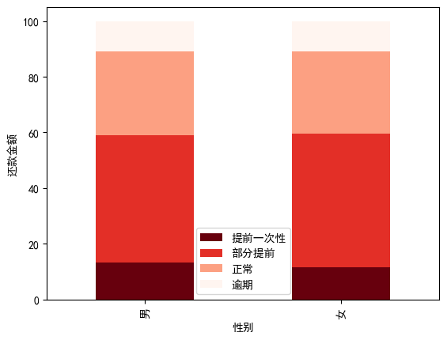

```python
male = LCLP.loc[LCLP['性别'] == "男"]
female = LCLP.loc[LCLP['性别'] == "女"]
sexgroup = (male,female)

repayhabit(sexgroup,2,sex_idx,'性别','Reds_r')
```

从对性别分组的统计结果以及上图结果中可以看出：

1. 该平台男性客户的贷款金额约为女性客户的2.7倍；
2. 男性及女性的还款习惯大体上比较一致，从金额上来说，部分提前还款>正常还款>一次性提前还款>逾期还款；
3. 男性客户一次性提前还款的金额占比较女性为高；
4. 女性逾期还款的风险略低于男性；
5. 女性部分提前还款的金额占比略大于男性。

### 3.3.4 不同初始等级用户的还款情况

```
[24944869.2574, 132720901.50000001, 294271989.10510004, 132631049.4704, 10810885.6777, 1523539.95]
       提前一次性       部分提前         正常         逾期
A  10.823224  41.586589  40.934311   6.655876
B   7.972043  37.125925  47.786938   7.115094
C  14.311310  49.856830  24.939672  10.892188
D  14.869547  49.104070  21.759505  14.266878
E  13.325911  40.924261  22.869896  22.879932
F  10.752586  41.241621  20.679682  27.326111
```

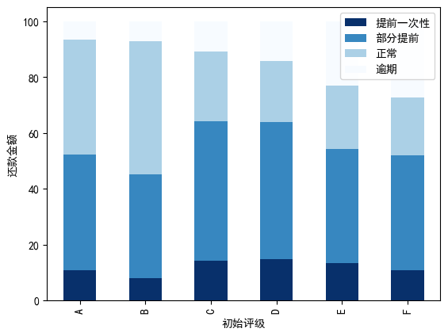

```python
levelgroup = []
for i in level_idx:
    l = LCLP[(LCLP['初始评级'] == i)]
    levelgroup.append(l)

repayhabit(levelgroup,6,level_idx,'初始评级','Blues_r')
```

从对初始评级分组的统计结果可以看出：

（2）提前一次性还款的占比相对比较平均，其中D级最大为14.87%。

（3）逾期风险随着级别而呈总体增加趋势，F级客户的逾期占比达到了27.33%。

（4）部分提前和正常还款还是占到了大多数。

（5）总的来说，初始评级具有重要的参考意义。

### 3.3.5 不同借款类型的用户还款情况

```
[88244351.8, 75868377.82, 235775058.99000004, 197015446.3506]
           提前一次性       部分提前         正常         逾期
电商      4.673480  26.718977  61.993099   6.614444
APP闪电   9.362065  60.731180  18.619492  11.287263
普通     17.281851  45.043032  26.040203  11.634914
其他     12.561180  51.106721  24.588974  11.743126
```

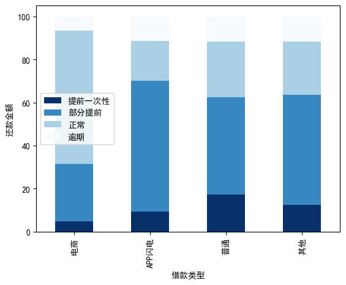

```python
kindgroup = []
for i in kind_idx:
    l = LCLP[(LCLP['借款类型'] == i)]
    kindgroup.append(l)

repayhabit(kindgroup,4,kind_idx,'借款类型','Blues_r')
```

从对借款类型分组的统计结果可以看出：

1. 普通借款类型的借款金额总数最大，其次是其他，电商和APP闪电差不多。
2. 逾期风险电商最低，为6.61%。其他三种类型差异较小。
3. 部分提前和正常还款还是占比较高。值得注意的是除了电商，其他三种类型的部分提前还款占比都比正常还款更高。

### 3.3.6 不同借款期限的用户还款情况

```
[139074905.6822, 109309753.26999998, 94399069.1, 75980911.56069998, 61087990.3239, 48299460.9903, 19195787.9202, 15773764.8425, 12375793.05, 9366561.910799999, 6707222.379999999, 4428904.62, 301556.79, 169422.24, 143763.04, 83483.42, 69138.15, 50308.28, 36507.18, 19895.030000000002, 17235.37, 7340.2…
        提前一次性       部分提前         正常         逾期
1   12.012067  46.924755  34.110889   6.952289
2   12.291779  50.537072  28.719085   8.452063
3   15.840456  46.416405  28.489988   9.253150
4   14.188810  44.121497  30.358465  11.331228
5   12.772179  44.090716  30.536874  12.600231
6    9.568324  44.100507  31.411984  14.919185
7   15.676046  44.990592  22.768091  16.565271
8   14.304974  44.305713  23.229640  18.159673
9   11.188413  44.708799  23.375853  20.726935
10  10.192059  44.199670  23.352395  22.255876
11   7.336843  43.166507  24.847309  24.649341
12   3.488976  46.292224  23.119075  27.099726
13  40.889877  19.431789  24.862965  14.815369
14  11.412274  31.494749  29.133761  27.959216
15  16.012787  28.809769  24.802021  30.375422
16   0.000000  29.785926  27.199592  43.014481
17   0.000000  17.118002  31.699792  51.182205
18   0.000000  20.567111  30.283941  49.148947
19   0.000000  21.394969  23.491982  55.113049
20   0.000000  23.093557  35.159937  41.746507
21  22.619068  16.714292  34.597227  26.069414
22   0.000000  72.794535  27.205465   0.000000
23   0.000000   0.000000  83.207610  16.792390
24        NaN        NaN        NaN        NaN
```

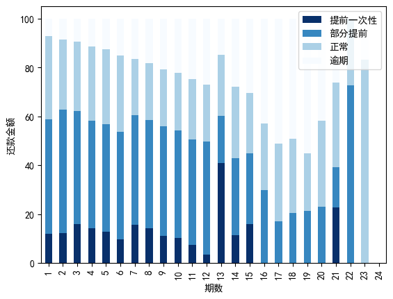

```python
term_idx = ('1','2','3','4','5','6','7','8','9','10','11','12','13','14','15','16','17','18','19','20','21','22','23','24')
termgroup = []
for i in range(1,25):
    term = LCLP.loc[(LCLP['期数'] == i)]
    termgroup.append(term)

repayhabit(termgroup,24,term_idx,'期数','Blues_r')
```

从对期数分组的统计结果可以看出：

1. 不同的还款行为在不同的借款期限下的表现差异比较大，部分提前还款和正常还款是最常用的方式；
2. 逾期风险随着借款期限变长而呈总体增加趋势，期限为19个月的逾期金额占比为最高，达到了55.11%；
3. 期限为13个月的提前一次性还款占比最高，达到了40.89%。
4. 借款期限太长的样本数量太少，不能排除偶然性。

```python
jupyter nbconvert --to html lending_data_analysis_report.ipynb
```

[output not shown]